# DNA Pattern are potential replication sites

# 2. Basic Analysis

### 2.1 Random Scatter

In this part, we will do the simulation study to see what the ramdom scatter looks like, and after severl simulations, we could compare our real data to the simulations.

Specifically here we set down that the total length is 229354, and the number of interval is 60, and sample size is 296

```r
# Open the file and redefine the make
setwd("~/Downloads")
dat <- read.table("hcmv.txt", header=TRUE)

N = 229354 # total length
n = 296 # sample size
k = 60 # number of intervals
expected = n/k
lambda = n/k
```

Simulation 1

```r
# set several numbers
set.seed(100)
sim1 <- sample.int(N, size=n, replace=FALSE)

# Histogram
hist(sim1, breaks = k, col = rgb(1,0,0,0.5))
abline(h = expected, col='black', lwd = 2)
```

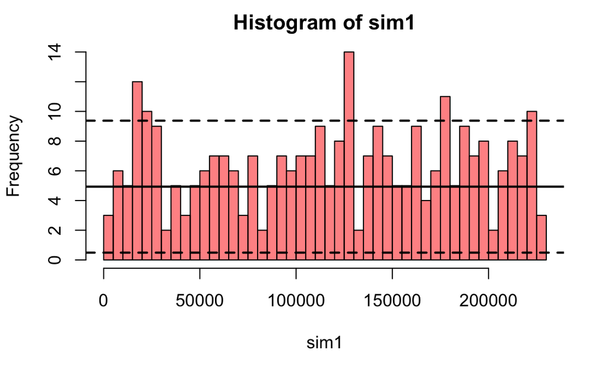

```r
abline(h = expected - 2*sqrt(lambda), col='black', lwd = 2, lty =2)
abline(h = expected + 2*sqrt(lambda), col='black', lwd = 2, lty =2)
```

Simulation 2

```r
set.seed(200)
sim2 <- sample.int(N, size=n, replace=FALSE)

# Histogram
hist(sim2, breaks = k, col = rgb(1,0,1,0.5))
abline(h = expected, col='black', lwd = 2)
```

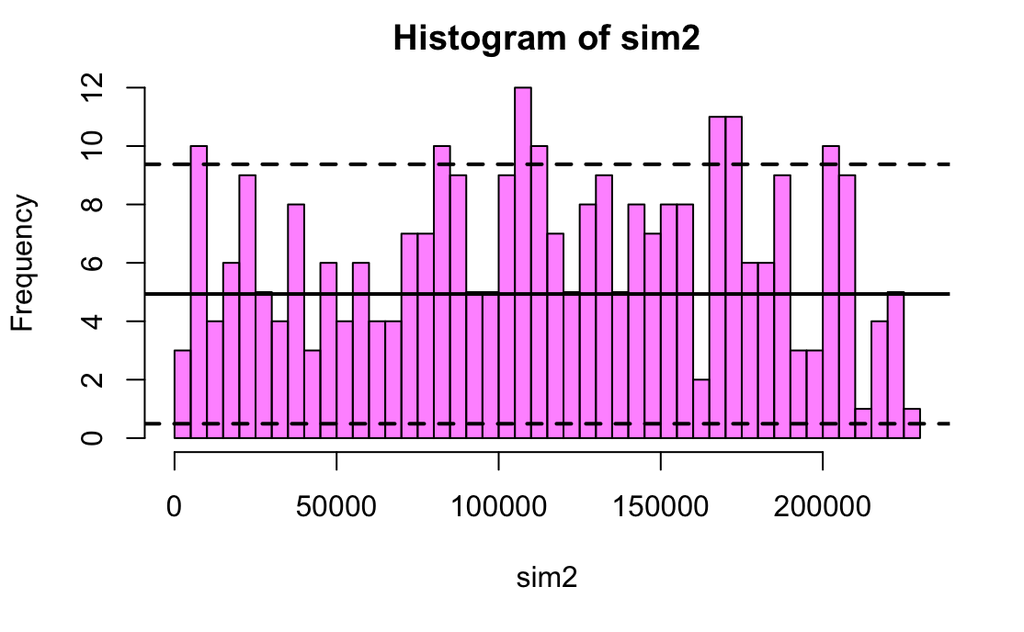

```r
abline(h = expected - 2*sqrt(lambda), col='black', lwd = 2, lty =2)
abline(h = expected + 2*sqrt(lambda), col='black', lwd = 2, lty =2)
```

Simulation 3

```r
set.seed(300)
sim3 <- sample.int(N, size=n, replace=FALSE)

# Histogram
hist(sim3, breaks = k, col = rgb(0.5,0,0,0.5))
abline(h = expected, col='black', lwd = 2)
```

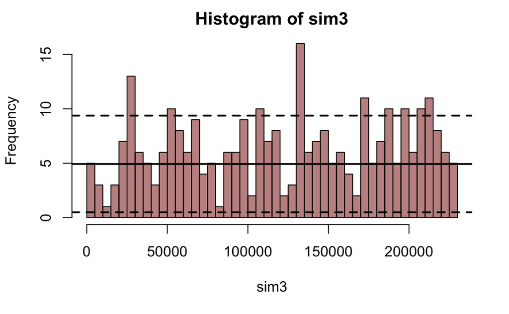

```r
abline(h = expected - 2*sqrt(lambda), col='black', lwd = 2, lty =2)
abline(h = expected + 2*sqrt(lambda), col='black', lwd = 2, lty =2)
```

Real data

```r
real <- dat$location

# Histogram
hist(real, breaks = k, col = "lightblue")
abline(h = expected, col='black', lwd = 2)
```

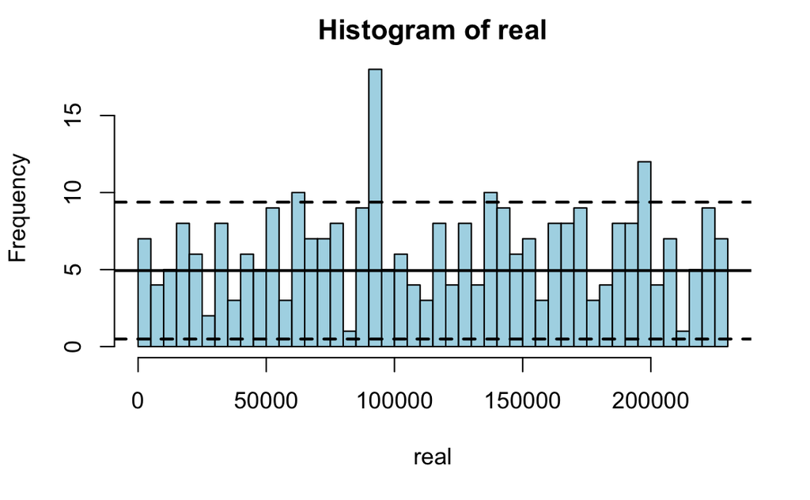

```r
abline(h = expected - 2*sqrt(lambda), col='black', lwd = 2, lty =2)
abline(h = expected + 2*sqrt(lambda), col='black', lwd = 2, lty =2)
```

Plot the cdf curves

```r
plot(ecdf(sim1),main = 'CDF curves', col = rgb(1,0,0,0.5), lwd = 2, do.point=FALSE)
plot(ecdf(sim2), col = rgb(1,0,1,0.5), lwd = 2, do.point=FALSE,add = TRUE)
```

```r
plot(ecdf(sim3), col = rgb(0.5,0,0,0.5), lwd = 2,do.point=FALSE, add = TRUE)
plot(ecdf(real), col = 'lightblue', lwd = 2, do.point=FALSE,add = TRUE)
```

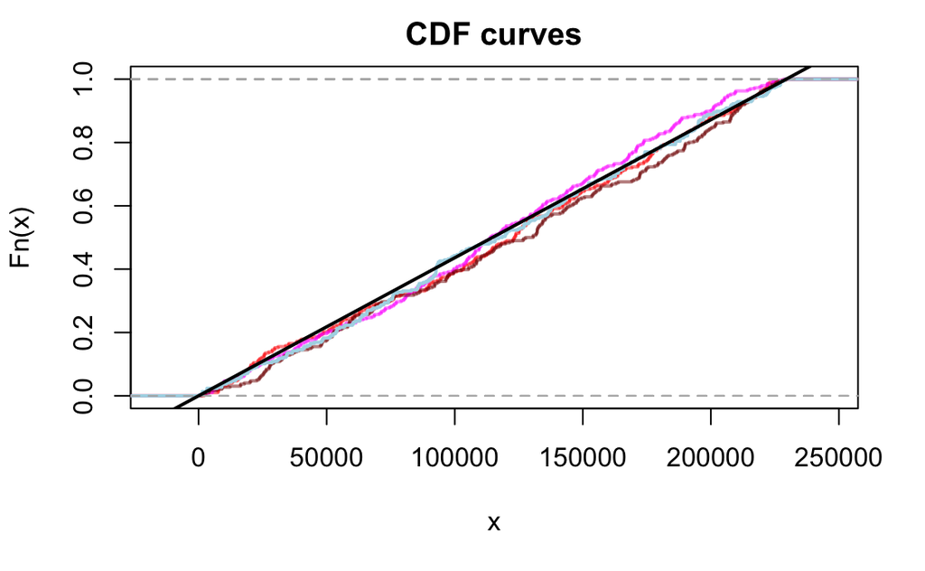

```r
abline(0, 1/N, col = 'black', lwd = 2)
```

### 2.2 Locations and spacings

In this part we will discovr the spacings between consecutive palindromes, and the sum of consecutive pairs, triplets.And check their distributions.

For real data

```r
# spacings between consecutive palindromes
spa1 = diff(real)

# spacing between sum of consecutive pairs
spa2 = rep(NULL, 294)
for(i in 1:294){
  temp1 = real[i] + real[i+1]
  temp2 = real[i+1] + real[i+2]
  diff1 = temp2 - temp1
  spa2[i] = diff1
}

# spacing between sum of consecutive triplets
spa3 = rep(NULL, 293)
for(i in 1:293){
  temp1 = real[i] + real[i+1] + real[i+2]
  temp2 = real[i+1] + real[i+2] + real[i+3]
  diff2 = temp2 - temp1
  spa3[i] = diff2
}
```

For simulaitions

```r
sim1_sorted = sort(sim1,decreasing = FALSE)
# spacings between consecutive palindromes
spa1s = diff(sim1_sorted)

# spacing between sum of consecutive pairs
spa2s = rep(NULL, 294)
for(i in 1:294){
  temp1 = sim1_sorted[i] + sim1_sorted[i+1]
  temp2 = sim1_sorted[i+1] + sim1_sorted[i+2]
  diff1s = temp2 - temp1
  spa2s[i] = diff1s
}

# spacing between sum of consecutive triplets
spa3s = rep(NULL, 293)
for(i in 1:293){
  temp1 = sim1_sorted[i] + sim1_sorted[i+1] + sim1_sorted[i+2]
  temp2 = sim1_sorted[i+1] + sim1_sorted[i+2] + sim1_sorted[i+3]
  diff2s = temp2 - temp1
  spa3s[i] = diff2s
}
```

Make the histogram of three different spacings

Spacings between consecutive palindromes

```r
hist(spa1, breaks = 15,main = 'Spacings between consecutive palindromes', col = rgb(1,0,0,0.5), probability = TRUE)
lines(density(spa1, adjust = 2), col = rgb(1,0,0,0.5))
```

```r
hist(spa1s, breaks = 15, col = rgb(0,0,1,0.5), probability = TRUE, add = TRUE)
lines(density(spa1s, adjust = 2), col = rgb(0,0,1,0.5))
```

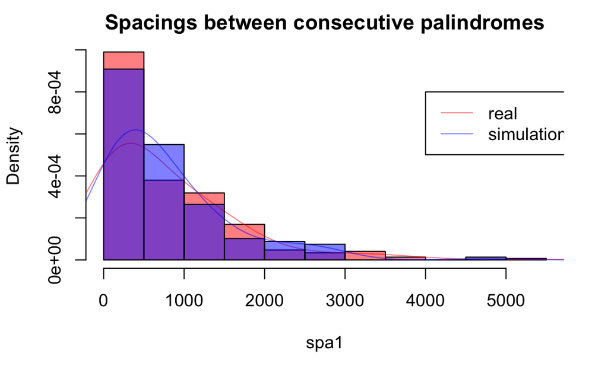

```r
legend(x = 4000, y = 8e-4, legend = c("real", "simulation"), lty = c(1,1), col = c(rgb(1,0,0,0.5), rgb(0,0,1,0.5)))
```

Spacing between sum of consecutive pairs

```r
hist(spa2, breaks = 15,main = 'Spacings between sum of consecutive pairs', col = rgb(1,0,0,0.5), probability = TRUE)
lines(density(spa1, adjust = 2), col = rgb(1,0,0,0.5))
```

```r
hist(spa2s, breaks = 15, col = rgb(0,0,1,0.5), probability = TRUE, add = TRUE)
lines(density(spa1s, adjust = 2), col = rgb(0,0,1,0.5))
```

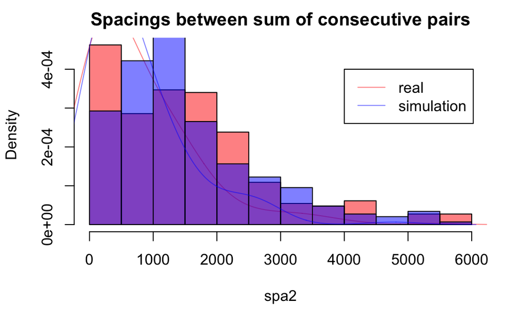

```r
legend(x = 4000, y = 4e-4, legend = c("real", "simulation"), lty = c(1,1), col = c(rgb(1,0,0,0.5), rgb(0,0,1,0.5)))
```

Spacing between sum of consecutive triplets

```r
hist(spa3, breaks = 15,main = 'Spacings between sum of consecutive triplets', col = rgb(1,0,0,0.5), probability = TRUE)
lines(density(spa1, adjust = 2), col = rgb(1,0,0,0.5))
```

```r
hist(spa3s, breaks = 15, col = rgb(0,0,1,0.5), probability = TRUE, add = TRUE)
lines(density(spa1s, adjust = 2), col = rgb(0,0,1,0.5))
```

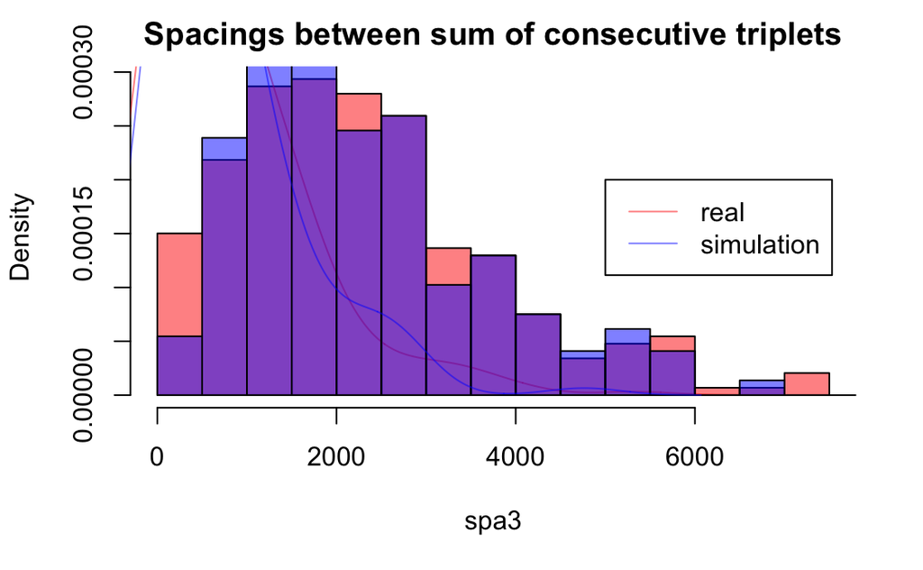

```r
legend(x = 5000, y = 0.0002, legend = c("real", "simulation"), lty = c(1,1), col = c(rgb(1,0,0,0.5), rgb(0,0,1,0.5)))
```

Plot the cumulative density curves

```r
# for real curves
plot(ecdf(spa1),main = 'CDF curves', col = "blue", lwd = 2, do.point=FALSE)
plot(ecdf(spa2), col = "red", lwd = 2, do.point=FALSE,add = TRUE)
```

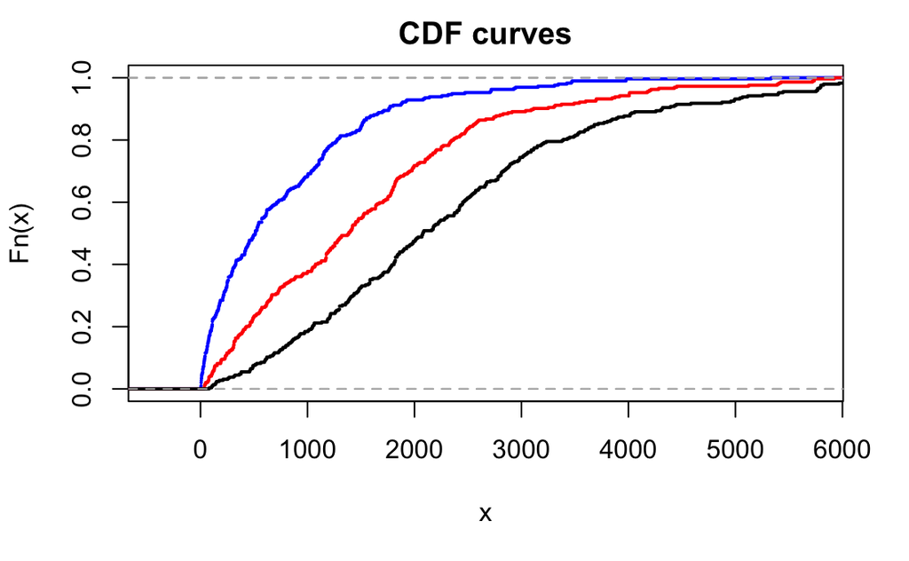

```r
plot(ecdf(spa3), col = "black", lwd = 2, do.point=FALSE,add = TRUE)
```

```r
# for expected curves
expected1 = rexp(295, rate= 1/(295/60))
plot(ecdf(expected1), main = "Expected curves",lwd = 2, col = "blue",do.point=FALSE)

expected2 = rgamma(294, shape = 2, rate = 1/(294/60))
plot(ecdf(expected2),lwd = 2, col = "red",add = TRUE, do.point=FALSE)
```

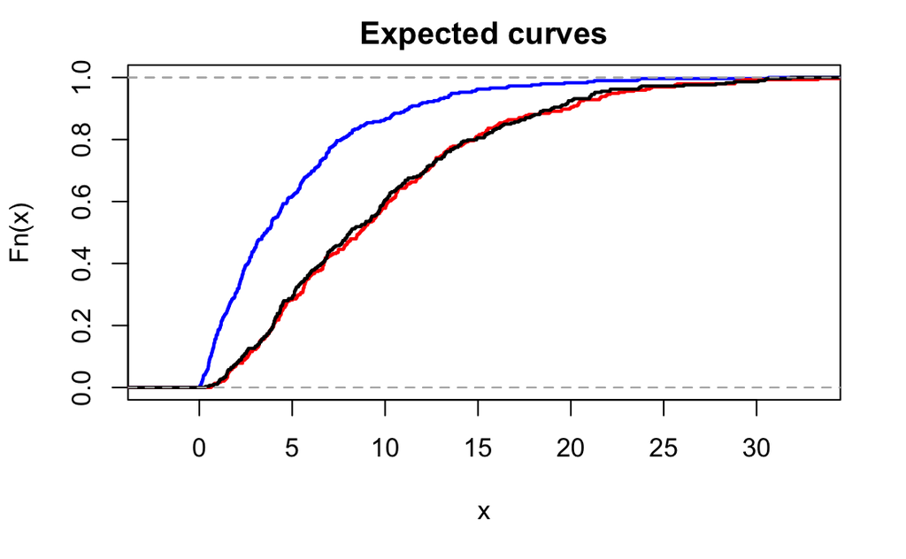

```r
expected3 = rgamma(293, shape = 2, rate = 1/(293/60))
plot(ecdf(expected3),lwd = 2, col = "black",add = TRUE, do.point=FALSE)
```

### 2.3 Counts

In this part, we gonna examine the counts of palindromes in various regions of the DNA by both graphical methods and statistical tests.

```r
#Helper function
regionsplit <- function(n.region, gene, site){
  count.int <- table(cut(site, breaks = seq(1, length(gene), length.out=n.region+1), include.lowest=TRUE))
  count.vector <- as.vector(count.int)
  count.tab <- table(factor(count.vector,levels=0:max(count.vector)))
  return (count.tab)
}
```

Histograms of counts for both simulation and real data

```r
# Find the counts in each intervels
tab <- table(cut(real, breaks = seq(0, N, length.out = k+1), include.lowest = TRUE))
tab_counts <- as.vector(tab)

# Plot the histogram
hist(tab_counts, breaks = 10, col = rgb(1,0,0,0.5), probability = TRUE, xlab = "number of points inside an interval")
lines(density(tab_counts, adjust = 2), col = rgb(1,0,0,0.5))
```

```r
Pois <- rpois(296, lambda = mean(tab_counts))
hist(Pois,breaks = 10, col = rgb(0,0,1,0.5), probability = TRUE, add = TRUE)
lines(density(Pois, adjust = 2), col = rgb(0,0,1,0.5))
```

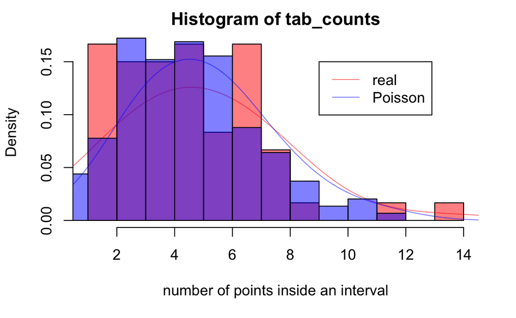

```r
legend(x = 9, y = 0.15, legend = c("real", "Poisson"), lty = c(1,1), col = c(rgb(1,0,0,0.5), rgb(0,0,1,0.5)))
```

Nonoverlaping interval counts

```r
# For simulation
set.seed(1000)
gene <- seq(1, N)
sim <- sample.int(N, size=n, replace=FALSE)
n.region = k
sim_tab = regionsplit(n.region, gene, sim)

# For real data
gene <- seq(1, N)
real_tab = regionsplit(n.region, gene, real)
```

Table with number of hits and expected number of intervals containing those numbers of hits

```r
trunc=7
lvls=factor(c(0:(trunc-1),paste(">=",trunc,sep="")),levels=c(0:(trunc-1),paste(">=",trunc,sep="")))
real.vector=as.vector(real_tab)

real_trunc=c(real.vector[1:trunc],sum(real.vector[-(1:trunc)]))


lambda=n/n.region
p=c(dpois(0:(trunc-1),lambda),1-sum(dpois(0:(trunc-1),lambda)))
E=p*n.region
tab1=data.frame(levels=lvls,Observed=real_trunc,Expected=E)

tab1
```

| levels | Observed | Expected |
| --- | --- | --- |
| 0 | 0 | 0.4321473 |
| 1 | 4 | 2.1319267 |
| 2 | 6 | 5.2587525 |
| 3 | 9 | 8.6477263 |
| 4 | 9 | 10.6655292 |
| 5 | 10 | 10.5233221 |
| 6 | 5 | 8.6525093 |
| >=7 | 17 | 13.6880866 |

```r
NA
NA
```

Chi-square Test

```r
chisq.test(real_trunc,p=p,simulate.p.value=TRUE)
```

```
    Chi-squared test for given probabilities with simulated p-value
    (based on 2000 replicates)

data:  real_trunc
X-squared = 4.8172, df = NA, p-value = 0.6702
```

Standardized residual plot

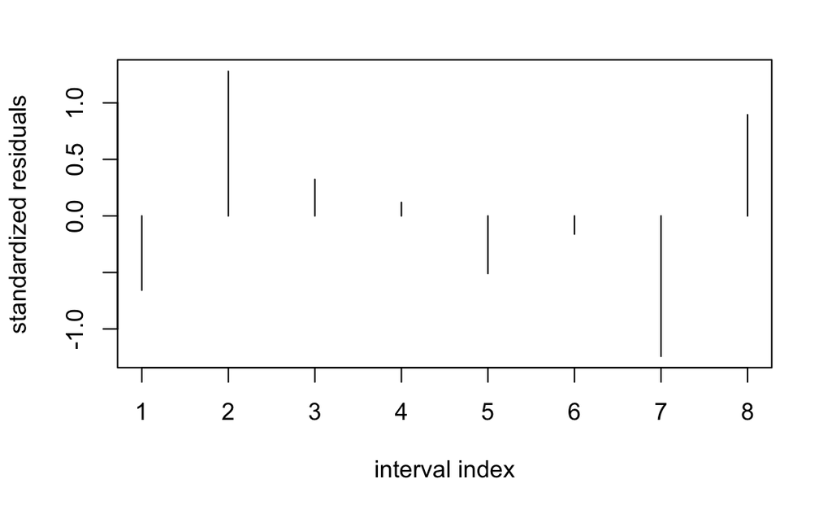

```r
Residuals <- (real_trunc - E) / sqrt(E)
plot(Residuals, type = 'h', ylab = "standardized residuals", xlab = "interval index")
```

### 2.4 The biggest cluster

In this part, we will go and check if the biggest count among 60 interval common which could indicate a potential origin of replications.By doing the simulation study we could find the distribution of maximum then we can compare the common one and what in the real data.

Find the biggest count among 60 intervals

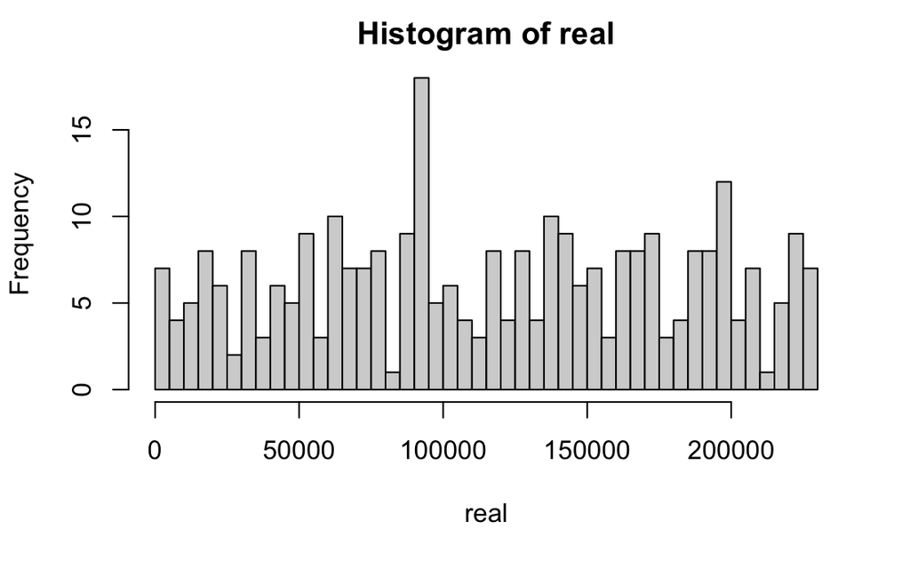

```r
R.hist = hist(real, breaks = 60)
```

```r
MC = max(R.hist$counts)
```

Simulation study to find the distribution of maximum

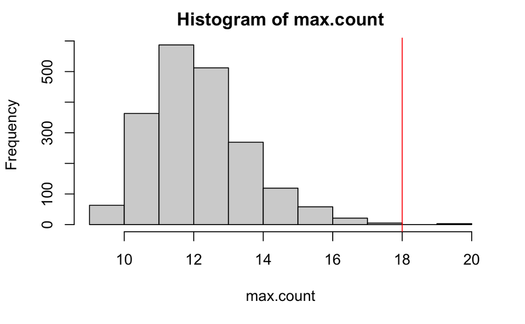

```r
nsim = 2000   # number of simulations

# Simulate data
max.count = rep(NULL, nsim)
for(i in 1:nsim) {
  X = sample(1:N, size = n, replace = F)
  X.hist = hist(X, breaks = k, plot = F)
  max.count[i] = max(X.hist$counts)
}

# Distribution of maximum
hist(max.count)

# Add a vertical line of real maximum count
abline(v = MC, col = "red")
```

Find the probability of max count is equal to the real max count in 2000 simulaitons.

```r
length(which(max.count == 18)) / 2000
```

```
[1] 0.0025
```

### 3. Advanced Analysis

In this part we will keep going to discover about spacing. Here we will go and analyize the spacing between sum of consecutive quadruplets

```r
# Spacing for real data
spa4 = rep(NULL, 292)
for(i in 1:292){
  temp1 = real[i] + real[i+1] + real[i+2] + real[i+3]
  temp2 = real[i+1] + real[i+2] + real[i+3] + real[i+4]
  diff3 = temp2 - temp1
  spa4[i] = diff3
}
# Spacing for simulation
spa4s = rep(NULL, 292)
for(i in 1:292){
  temp1 = sim1_sorted[i] + sim1_sorted[i+1] + sim1_sorted[i+2] + sim1_sorted[i+3]
  temp2 = sim1_sorted[i+1] + sim1_sorted[i+2] + sim1_sorted[i+3] + sim1_sorted[i+4]
  diff3s = temp2 - temp1
  spa4s[i] = diff3s
}
```

Plot the cdf

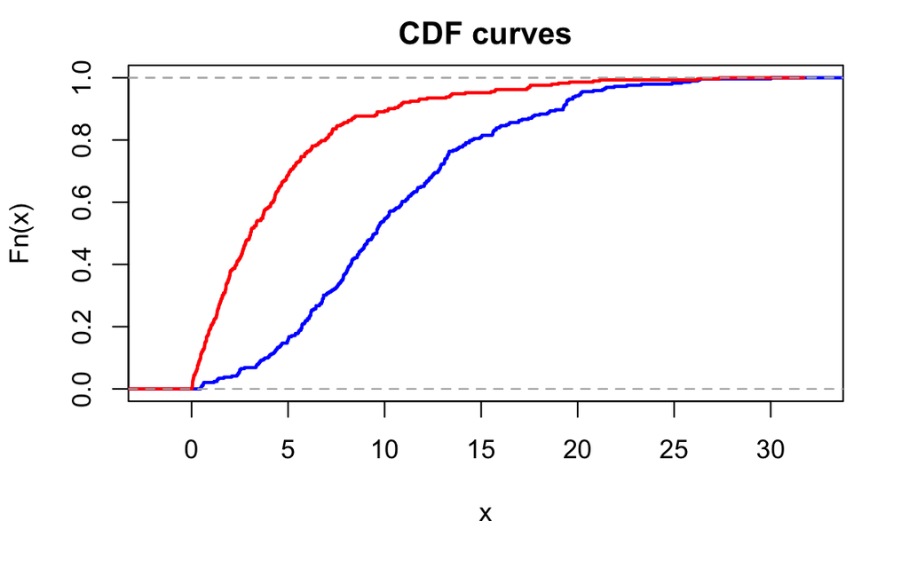

```r
plot(ecdf(spa4/300),main = 'CDF curves', col = "blue", lwd = 2, do.point=FALSE)

# for expected curves
expected4 = rexp(292, rate= 1/(292/60))
plot(ecdf(expected4), main = "Expected curves",lwd = 2, col = "red",add = TRUE,do.point=FALSE)
```

Find the hist

```r
hist(spa4, breaks = 15,main = 'Spacings between sum of consecutive quadruplets', col = rgb(1,0,0,0.5), probability = TRUE)

hist(spa4s, breaks = 15, col = rgb(0,0,1,0.5), probability = TRUE, add = TRUE)
```

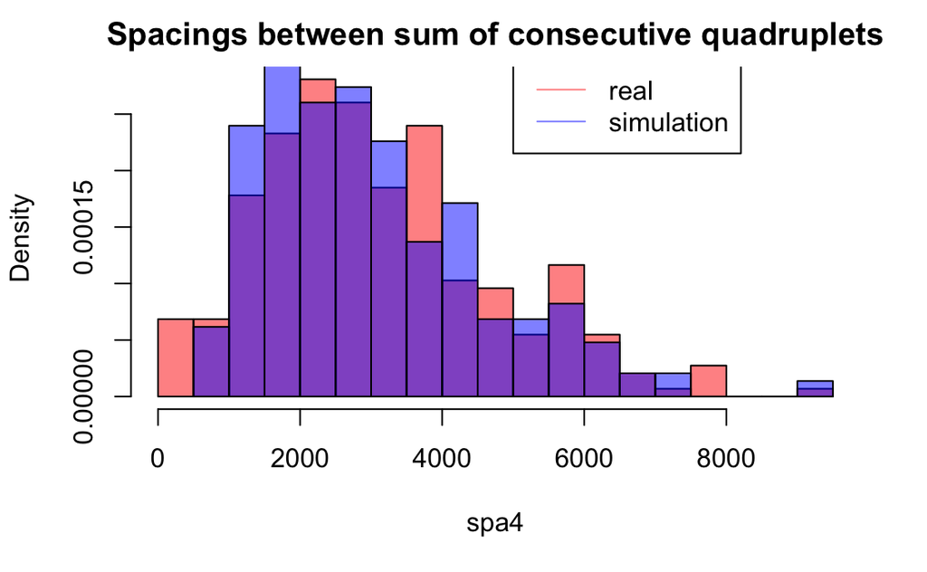

```r
legend(x = 5000, y = 0.0003, legend = c("real", "simulation"), lty = c(1,1), col = c(rgb(1,0,0,0.5), rgb(0,0,1,0.5)))
```